# A Two Page Guide to R

For Applied Researchers and Program Evaluators

Andy Grogan-Kaylor

February 24, 2019

# 1 Why?

R has a reputation for being difficult to learn, and a lot of that reputation is deserved.

[R](https://www.r-project.org/) is open source, and therefore free, statistical software that is particularly good at obtaining, analyzing and visualizing data.

I believe that it is possible to teach R in an accessible way, and that **a little bit of R can take you a long way**.

A great deal of data analysis and visualization involves the same core set of steps: get some data, clean it up a little, run some descriptive statistics, run some bivariate statistics, create a table or a graph or a visualization.

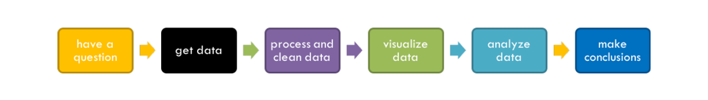

Given the fact that we often want to apply the same core set of tasks to new questions and new data, there are ways to overcome the steep learning curve and learn a replicable set of commands that can be applied to problem after problem. The same 5 to 10 lines of R code can often be tweaked over and over again for multiple projects.

# 2 Get R[^1]

R Commands are stored in a *script* or *code* file that usually ends in .R, e.g. `myRscript.R`. The command file is distinct from your actual data, stored in an .RData file, e.g. `mydata.RData`.

# 3 Get Data[^2]

```r
load("the/path/to/mydata.Rdata") # data in R format

library(foreign) # library for importing data
mydata <- read.spss("the/path/to/mySPSSfile.sav") # SPSS
mydata <- read.dta("the/path/to/myStatafile.dta") # Stata

library(readxl) # library for importing Excel files
mydata <- read_excel("the/path/to/mySpreadsheet.xls")

save(mydata, file = "mydata.RData") # save your data in R format
```

R makes a strong distinction between *continuous* *numeric* variables that measure scales like mental health or neighborhood safety, and *categorical* *factor variables* that measure non-ordered categories like religious identity or gender identity. Many statistical and graphical procedures are designed to recognize and work with different variable types.

# 4 Manage Data [^3]

```r
mydata$x[mydata$x == -9] <- NA # missing to NA
```

```r
mydata$w <- factor(mydata$z, # original numeric variable
                   levels = c(0, 1, 2),
                   labels = c("Group A", "Group B", "Group C"),
                   ordered = TRUE) # whether order matters

mydata$z <- as.numeric(mydata$w) # factor / character to numeric
```

# 5 Visualize Data

## 5.1 Histogram

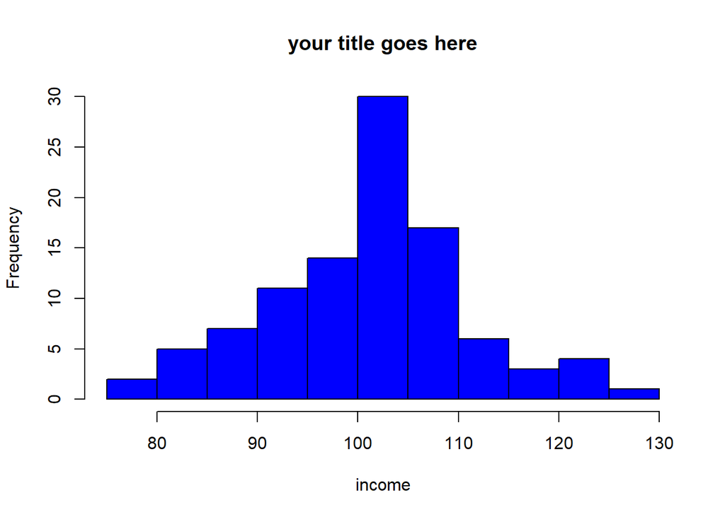

```r
hist(mydata$x, # what I'm graphing
     main = "your title goes here", # title
     xlab = "income", # label for x axis
     col = "blue") # color
```

You *don’t* need to use all of the options. e.g. `hist(mydata$x)` will work just fine.

## 5.2 Barplot

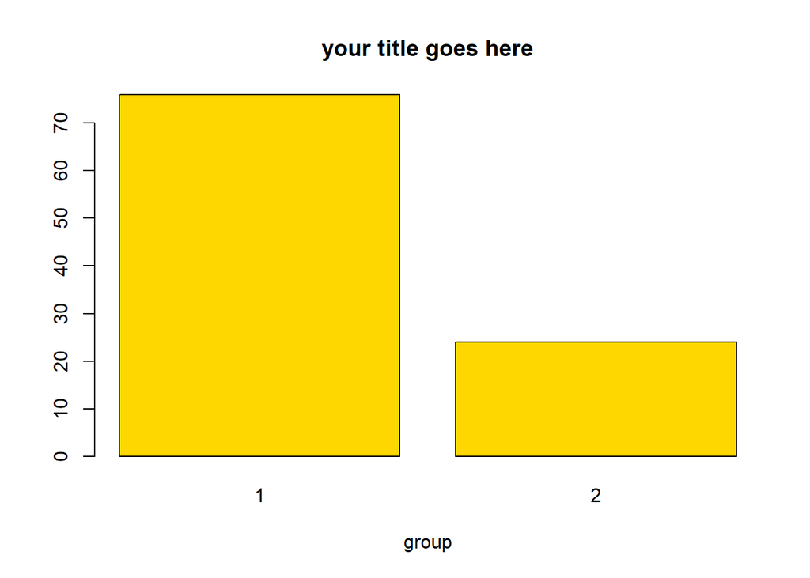

```r
barplot(table(mydata$z), # what I'm graphing
        main = "your title goes here", # title
        xlab = "group", # label for x axis
        col = "gold") # color
```

You *don’t* need to use all of the options. e.g. `barplot(table(mydata$z))` will work just fine.

## 5.3 Scatterplot

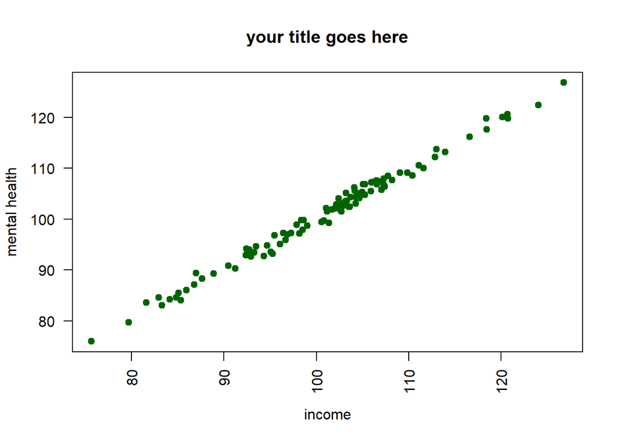

```r
plot(mydata$x,mydata$y, # plot x and y
     main = "your title goes here", # title
     xlab = "income", # label for x axis
     ylab = "mental health", # label for y axis
     pch = 19, # Plot CHaracter, 19 is filled dots
     las = 2, # LAbel Style, 2 is "perpendicular"
     col = "darkgreen") # color
```

# 6 Descriptive Statistics

```r
summary(mydata$x) # for continuous or factor variables
```

```
##    Min. 1st Qu.  Median    Mean 3rd Qu.    Max.
##   75.63   94.97  102.55  101.03  106.30  126.80
```

```r
table(mydata$z) # especially suitable for factor variables
```

```
##
##  1  2
## 76 24
```

# 7 Credits

Prepared by [Andy Grogan-Kaylor](https://agroganweb.wordpress.com/)